# Data Explorer Package in R

Felipe Pincheira-Berthelon

# Load in Packages

```r
library(mice)
library(tidyverse)
library(DataExplorer)
```

# Introduction

When it comes to exploring your data, there are many things you ought to consider. It is also likely that through your statistical training you may already have your own way of exploring data. But what if there was an easier way to get a good understanding of your data using `R`? Well, hopefully that’s `DataExplorer` package can provide.

The `DataExplorer` package provides information about data structure, missing values, frequencies, correlations, and even can even provide a principal component analysis. The best part of all, these are all functions ready to use with minimal code writing.

# Data

For this walk through, we will be referring to the `mtcars` dataset pre-loaded into `R`.

We will also be using a modified version of the `mtcars` dataset which contains missing values for demonstration purposes.

The code below shows exactly how we will be refereeing to these two datasets throughout.

Note: Remember to load in the `tidyverse` package for replication.

```r
data <- mtcars
```

```r
data_na <- mtcars %>%
     mutate(mpg=replace(mpg, cyl==4, NA)) %>%
     as.data.frame()
```

## Data Overview

A feature that is very convenient from `DataExplorer` is being able to look at a table with all the information. Below, we can compare how a complete dataset looks like vs a dataset with missing values by clicking the different headers.

We can see that the `introduce` function provides a very quick summary of how the dataset looks like overall.

### Regular Data

```r
introduce(data)
```

```
##   rows columns discrete_columns continuous_columns all_missing_columns
## 1   32      11                0                 11                   0
##   total_missing_values complete_rows total_observations memory_usage
## 1                    0            32                352         5928
```

### Data w/NA

```r
introduce(data_na)
```

```
##   rows columns discrete_columns continuous_columns all_missing_columns
## 1   32      11                0                 11                   0
##   total_missing_values complete_rows total_observations memory_usage
## 1                   11            21                352         5928
```

### Note

Note: This function produces a nice looking table which resembles the one showed below from the vignette demonstrating features of the package. It is possible that it may not be displaying from my machine, the package is still being updated, or they made their own table for their examples.

|  | value |
| --- | --- |
| rows | 32 |
| columns | 11 |
| discrete_columns | 0 |
| continuous_columns | 11 |
| all_missing_columns | 0 |
| total_missing_values | 0 |
| complete_rows | 32 |
| total_observations | 352 |
| memory_usage | 5928 |

## Data Overview Visualization

We can also take a look at a graphical representation of our data overview using the `plot_intro` function.

We can see from both of the previous methods that none of the variables are immediately considered discrete, however, if we look at the documentation for the `mtcars` dataset, we may want to alter some of those. This would be a great example of making sure your variables are the appropriate types in a dataset.

Additionally, from both of these overviews we gain insight into not only what types of variables our dataset has and how many, but also if any columns are missing, if any rows are missing, the total percentage of missing values and even the amount of memory the dataframe is.

### Regular Data

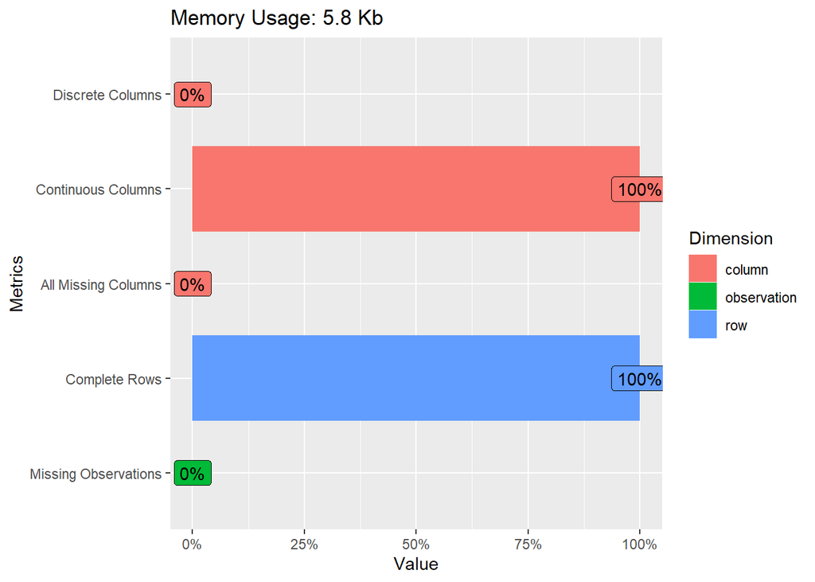

```r
plot_intro(data)
```

### Data w/NA

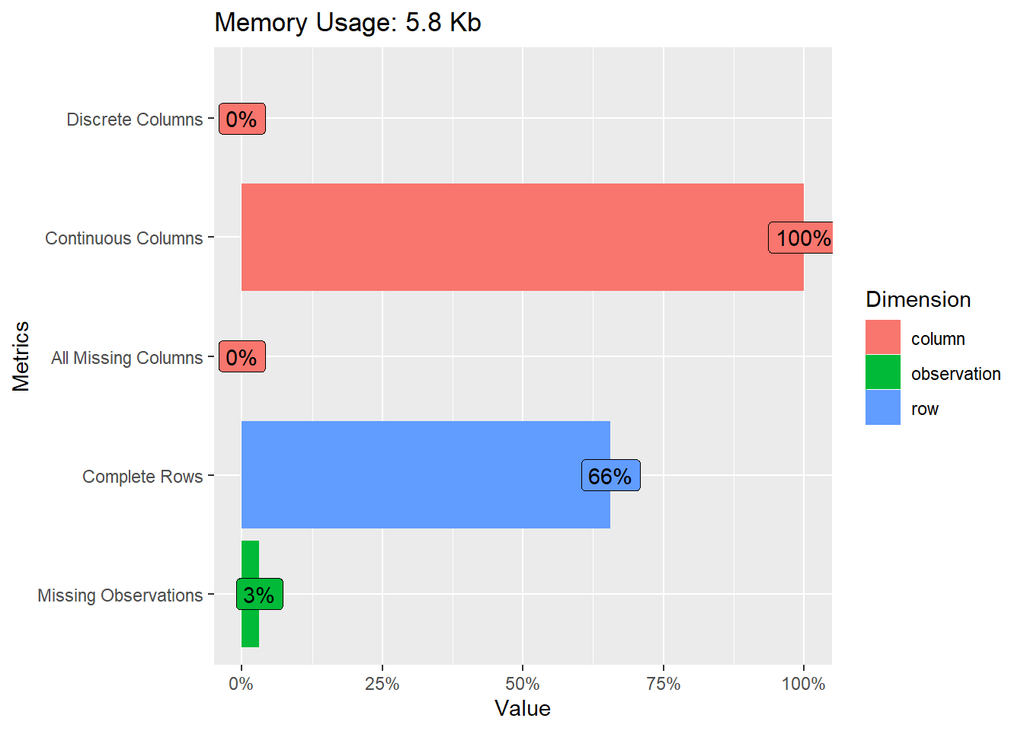

```r
plot_intro(data_na)
```

## Missing Data

Checking for missing data is another important step in exploring a new dataset. Using this package, we can use the `plot_missing` function to get a visualization of what may be missing in a dataset.

`DataExplorer` also provides recommendations as tow what to do with missing data if any are missing. This can be seen in the second plot where the percentage of missing values are given along with a recommendation of “Good”, “OK”, and not seen in the plot below is “Remove”. These recommendations simply imply that there is a “good” amount, an “OK” amount or a few missing values, and “remove” would suggest that there are too many missing values, so it might be best to remove the data.

### Regular Data

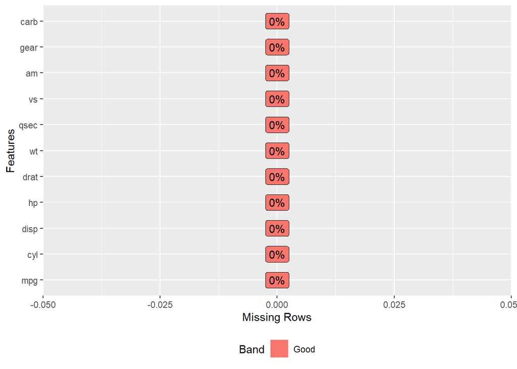

```r
plot_missing(data)
```

### Data w/NA

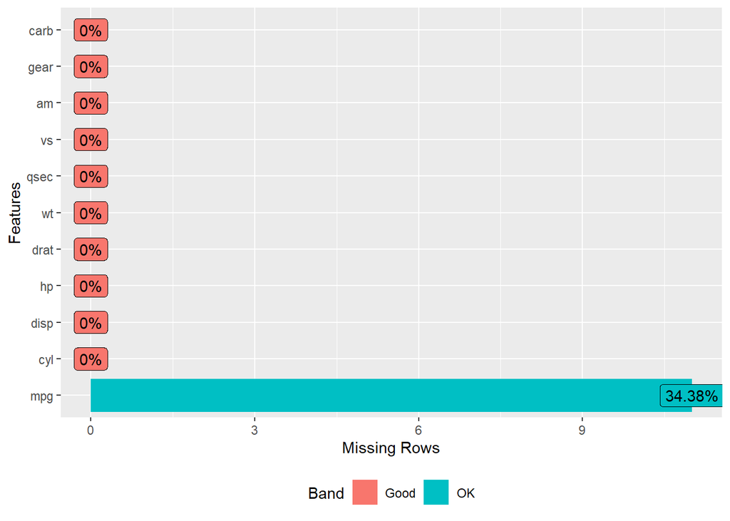

```r
plot_missing(data_na)
```

## Comparing Missing Data Visualizations

We can compare this to another popular way to view missing data, the `mice` package. While the `mice` package is primarily known for data imputation, it also has a a function `md.pattern` which also allows for a visualization of missing data which we can see using our data as well. We can see both methods provide a quick easy way to get an idea of what values what be missing, however, we can also see that `DataExplorer` goes just one step further providing not only a good looking visual, but even recommendations for how to approach the missing values.

### Regular Data

```
##  /\     /\
## {  `---'  }
## {  O   O  }
## ==>  V <==  No need for mice. This data set is completely observed.
##  \  \|/  /
##   `-----'
```

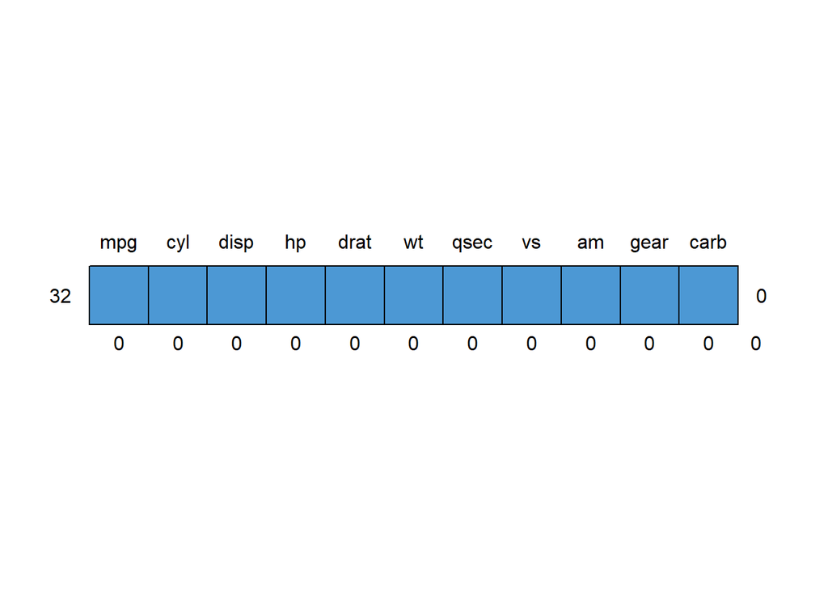

```
##    mpg cyl disp hp drat wt qsec vs am gear carb
## 32   1   1    1  1    1  1    1  1  1    1    1 0
##      0   0    0  0    0  0    0  0  0    0    0 0
```

```r
md.pattern(data)
```

### Data w/NA

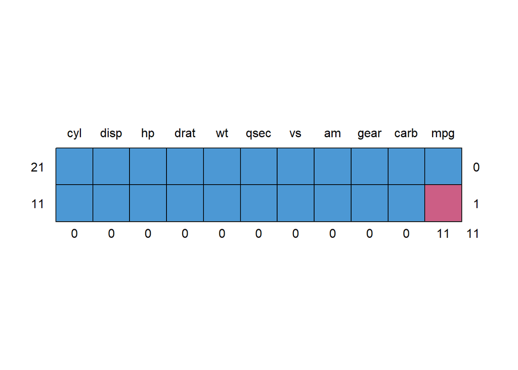

```
##    cyl disp hp drat wt qsec vs am gear carb mpg
## 21   1    1  1    1  1    1  1  1    1    1   1  0
## 11   1    1  1    1  1    1  1  1    1    1   0  1
##      0    0  0    0  0    0  0  0    0    0  11 11
```

```r
md.pattern(data_na)
```

## Discrete Bar Plots

The `DataExplorer` also provides a quick easy way to look at bar plots using the `plot_bar` function. We can see that using our unmodified data, `DataExplorer` will automatically facet plots. It will also try to auto recognize any discrete variable, and we can see this with binary variable being plotted even as a numeric type of variable in the dataset. Lastly, if you are interested in only looking at a specific bar plot, you can specify which variable by extracting it from the dataset and can be seen below.

### All Data

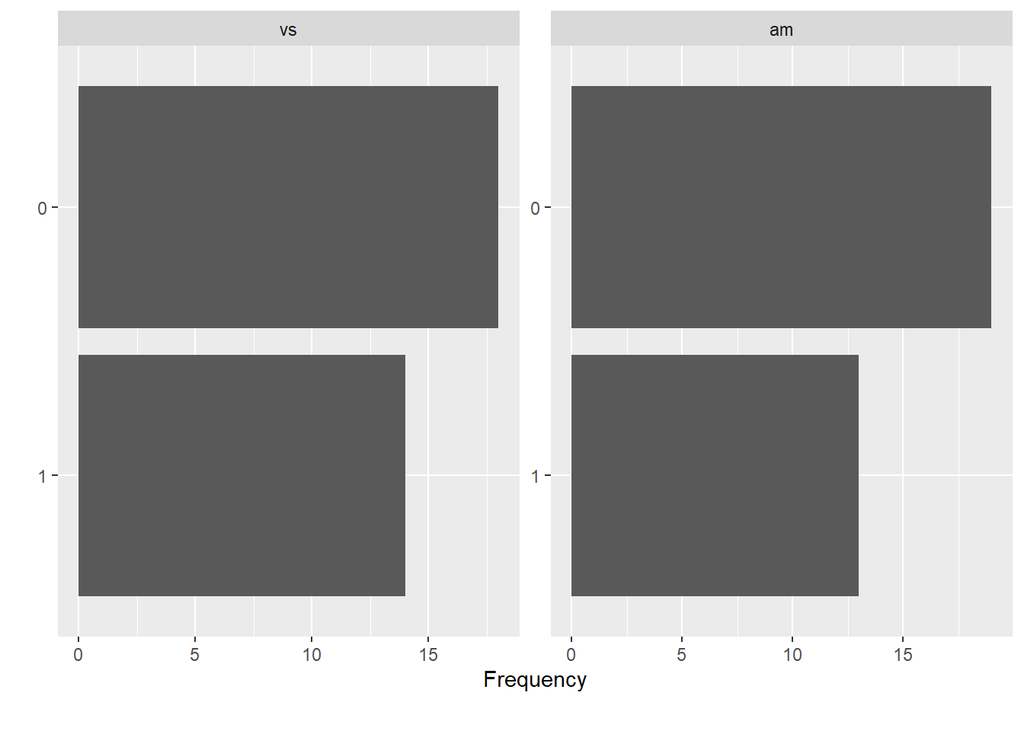

```r
plot_bar(data)
```

### Looking at One

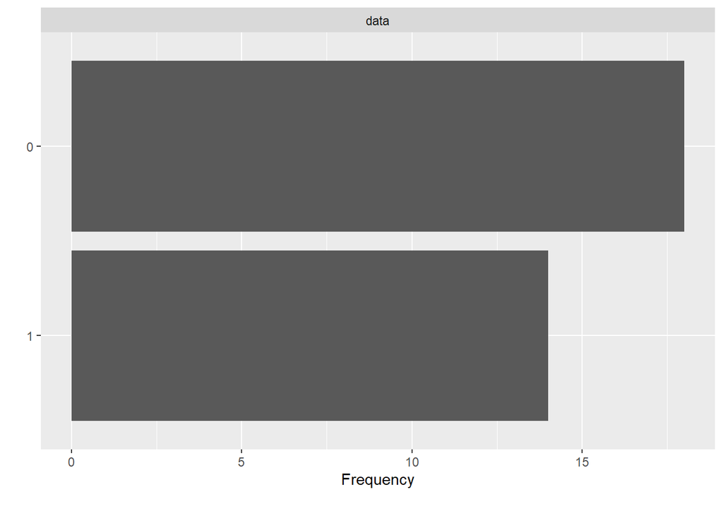

```r
plot_bar(data$vs)
```

## Histograms

Similarly to bar plots, histograms are automatically faceted using the `plot_histogram` function. A specific variable can be viewed like we did for the bar plot.

### All Data

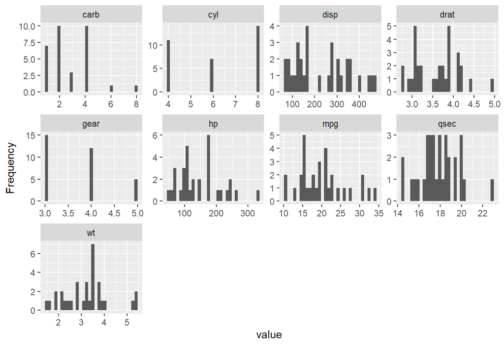

```r
plot_histogram(data)
```

### Looking at One

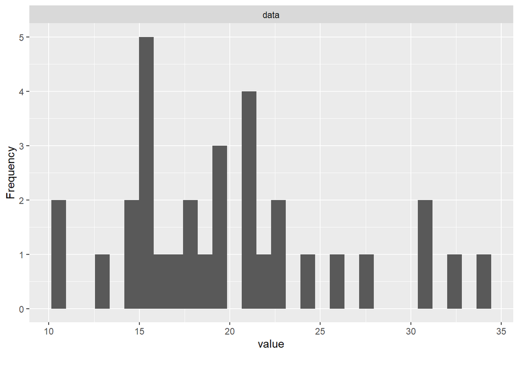

```r
plot_histogram(data$mpg)
```

## qq-plots

Like the two methods previously mentioned `plot_qq` will provide faceted plots of theoretical values.

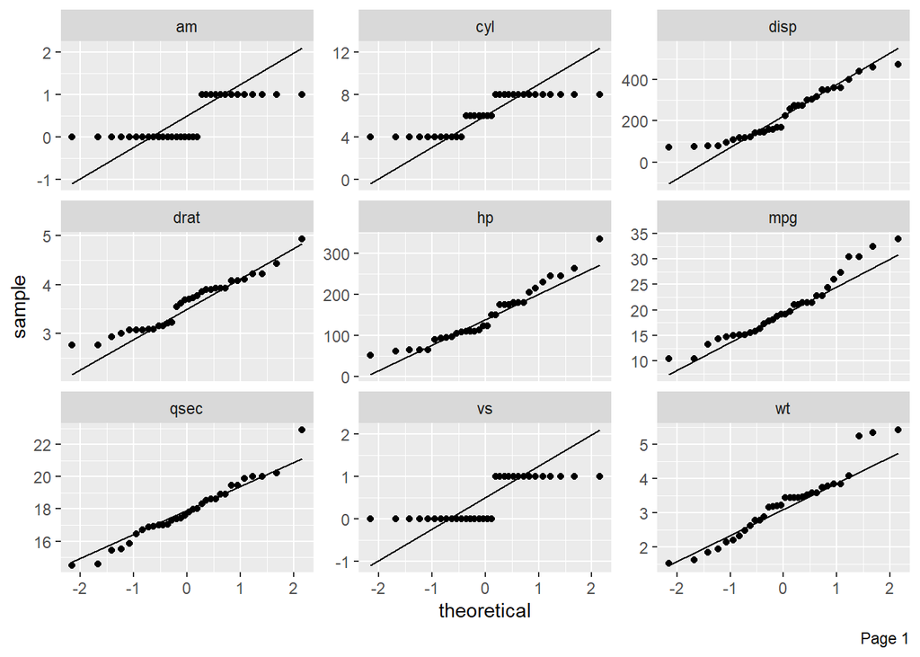

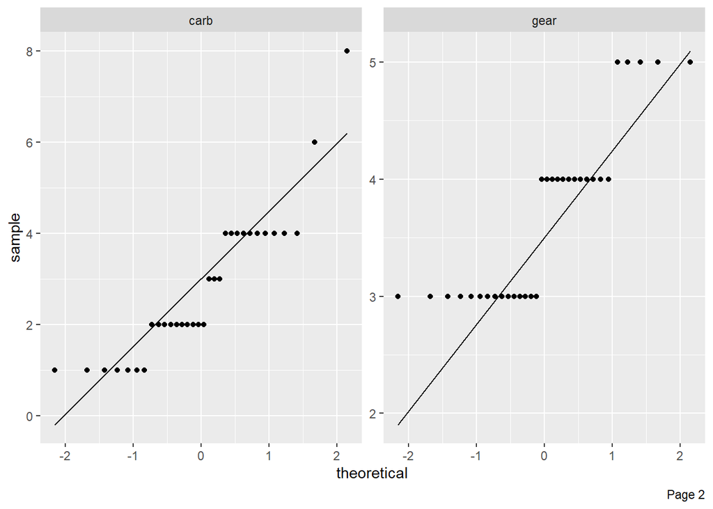

```r
plot_qq(data)
```

## Correlations

`DataExplorer` also easily plots correlations with the `plot_correlation` function. You can can get a quick and easy to read correlation table with just the one line of code.

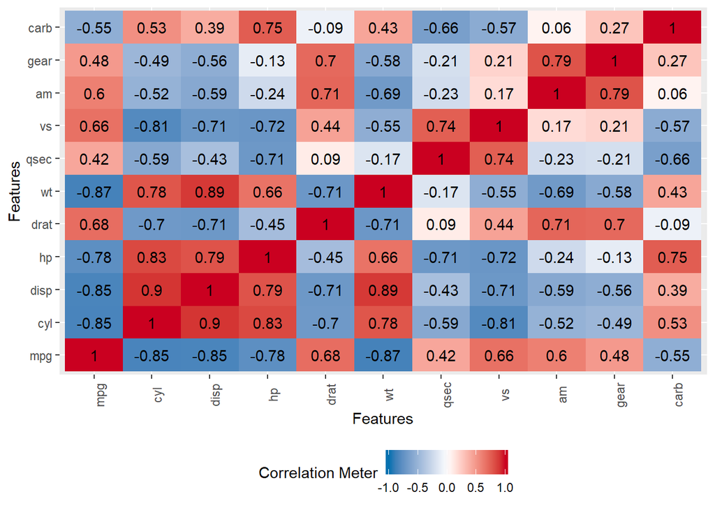

```r
plot_correlation(data)
```

## Principal Component Analysis

The last function I wanted to show is `plot_prcomp` which will provide us a visualization of a principal component analysis. We can specify the variance cap which is the maximum cumulative explained variance allowed for all principal components and then your plots are ready to go.

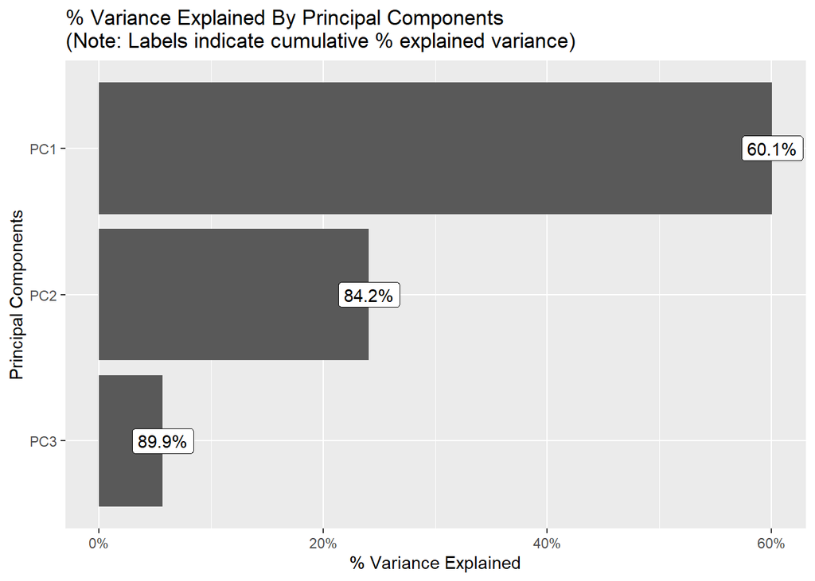

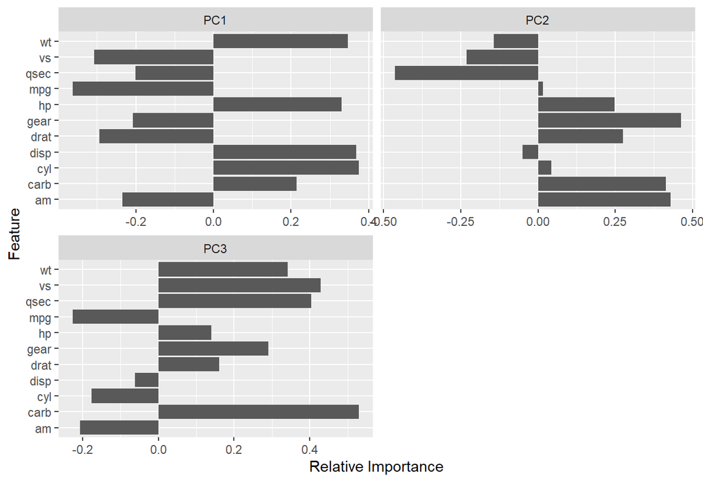

```r
plot_prcomp(data, variance_cap = 0.9, nrow = 2L, ncol = 2L)
```

# Conclusion

As we have just seen, `DataExplorer` makes the process of exploring your data easy. You could essentially copy the next block of code for yourself and get a good understanding of what your data looks like.

```r
plot_intro(data)
plot_missing(data)
plot_bar(data)
plot_histogram(data)
plot_qq(data)
plot_correlation(data)
plot_prcomp(data)
```

Instead of making your own plots or many other packages to explore data, `DataExplorer` does a good job streamlining this process and really only requiring one library call. Of course, `DataExplorer` may not be very helpful afterwards with data manipulation, however, the strength of this package is reducing the amount of time you will need to spend writing code to normally get these types of visualizations.

There are several other functions and features included in `DataExplorer` and I would strongly encourage everyone to consider trying this package out for themselves.

For more information and examples: https://cran.r-project.org/web/packages/DataExplorer/vignettes/dataexplorer-intro.html#data